##### —

# Introduction

Although there was a lot of data available, I lost some time finding data with which I could establish relationships and perform analysis. However, I eventually decided to examine the data on “Online Shopping”,“Consumer Confidence Index” and “Total Number of Closed Businesses” and to conduct regressions on these topics. These were subjects of interest to me. While examining the changes in these data, I had the opportunity to discover new things.

First of all, let’s install packages and read our data.

```r
require(data.table)
require(lubridate)
require(forecast)
require(skimr)
require(repr)
require(openxlsx) #library(openxlsx)
```

```r
require(ggplot2)
require(data.table)
require(skimr)
require(GGally)
require(ggcorrplot)
require(forecast)

library(data.table)
library(lubridate)
library(forecast)
library(skimr)
library(repr)
library(readxl)
options(repr.plot.width=12.7, repr.plot.height=8.5)
data <- read_excel("/Users/İbrahim/Downloads/data.xlsx")
data <- data
data=data.table(data)
head(data,25)
```

```
##          Tarih int_alisverisi bayram_search indirim_search
##         <POSc>          <num>         <num>          <num>
##  1: 2014-03-01       16788114             4             20
##  2: 2014-04-01       16693561             5             19
##  3: 2014-05-01       21532567             4             21
##  4: 2014-06-01       17550121             5             20
##  5: 2014-07-01       19952251            38             19
##  6: 2014-08-01       21683885             4             19
##  7: 2014-09-01       18289581            10             22
##  8: 2014-10-01       21838098            33             19
##  9: 2014-11-01       18902375             3             24
## 10: 2014-12-01       20619024             4             26
## 11: 2015-01-01       26746173             3             24
## 12: 2015-02-01       20967967             3             27
## 13: 2015-03-01       20634140             4             26
```

[output cut: 69 more lines]

```r
str(data)
```

```
## Classes 'data.table' and 'data.frame':   118 obs. of  12 variables:
##  $ Tarih                 : POSIXct, format: "2014-03-01" "2014-04-01" ...
##  $ int_alisverisi        : num  16788114 16693561 21532567 17550121 19952251 ...
##  $ bayram_search         : num  4 5 4 5 38 4 10 33 3 4 ...
##  $ indirim_search        : num  20 19 21 20 19 19 22 19 24 26 ...
##  $ tüketici_güven_endeksi: num  92.4 97.4 95.1 93.5 93.7 ...
##  $ ticari_faiz           : num  16.1 15.1 14.2 13.5 12.9 ...
##  $ reel_güven_indeksi    : num  106 111 114 110 107 ...
##  $ ...8                  : logi  NA NA NA NA NA NA ...
##  $ toplam_kapanan_isyeri : num  1073 937 968 1120 1136 ...
##  $ toplam_isgucu         : num  28462 28520 28421 28889 28541 ...
##  $ toplam_ofis           : num  237 76 82 104 107 77 127 85 102 146 ...
##  $ finans_güven_endeksi  : num  158 157 141 165 182 ...
##  - attr(*, ".internal.selfref")=<externalptr>
```

## Model 1

Let’s start by examining the “Online Shopping” topic. We can begin our analysis by looking at our data.

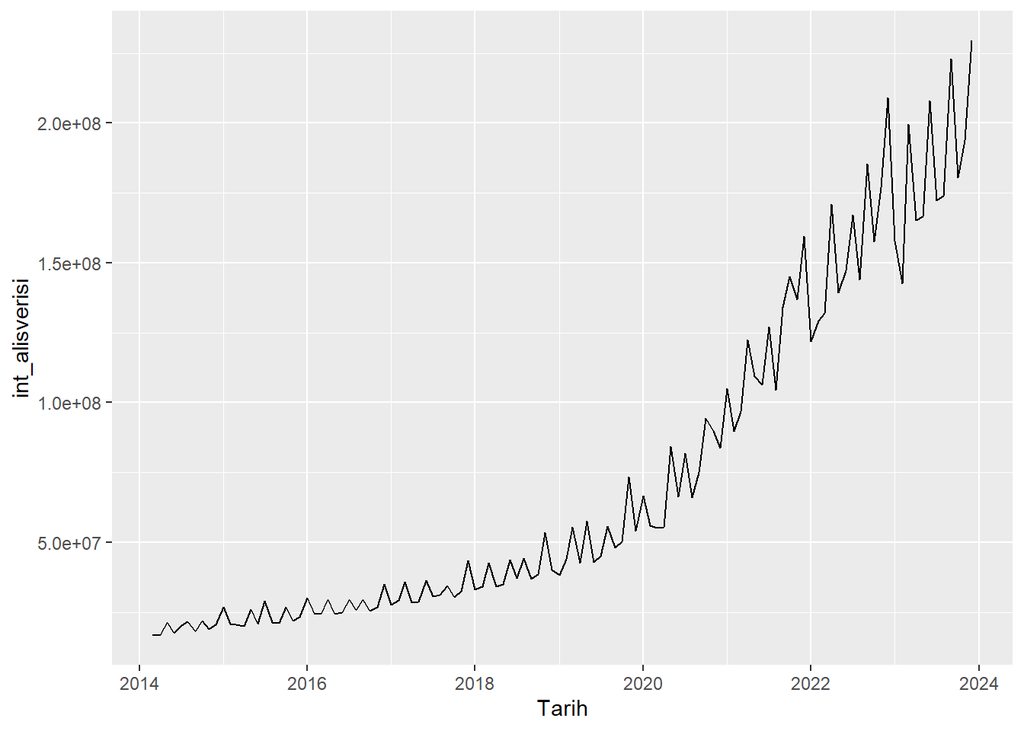

```r
ggplot(data ,aes(x=Tarih,y=int_alisverisi, group=1)) + geom_line()
```

When analyzing the topic of online shopping, considering Google searches related to holidays and discounts can be very helpful for our analysis. Let’s explore the relationship between these searches and our topic.

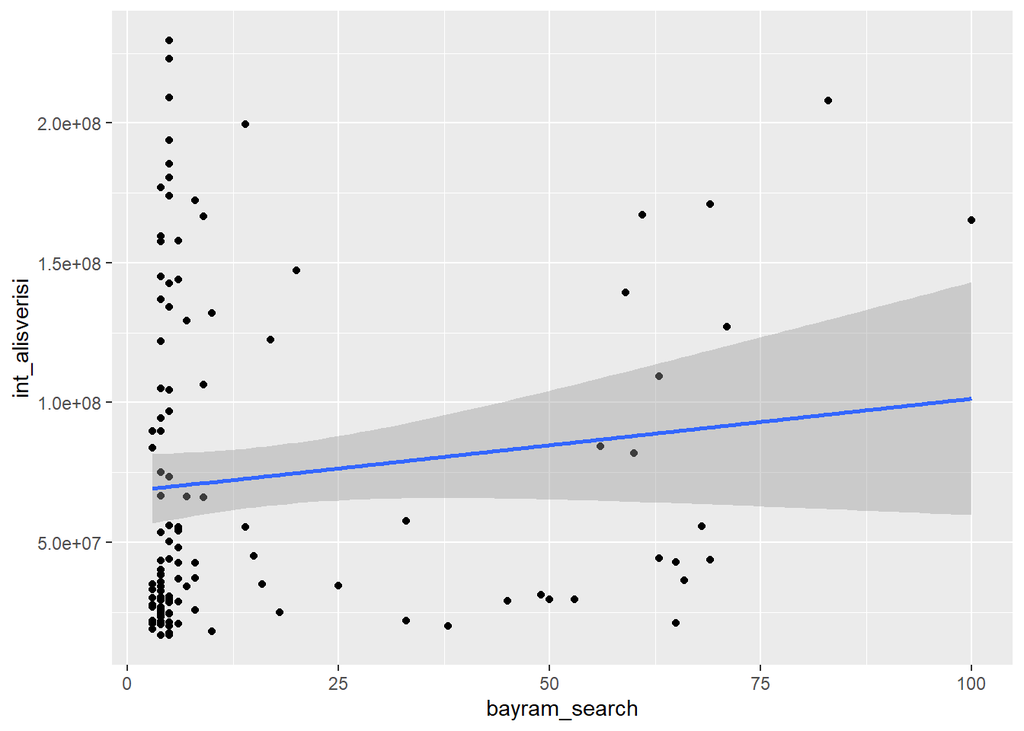

```r
ggplot(data ,aes(x=bayram_search,y=int_alisverisi)) + geom_point() +geom_smooth(method='lm')
```

Now, let’s create a plot to see the correlation by month. Note:Running this code chunk once is enough for the whole progress.

```r
data[,trnd:=1:.N]
data[,mon:=as.character(month(Tarih,label=T))]
data[,yıl:=as.character(year(Tarih))]
```

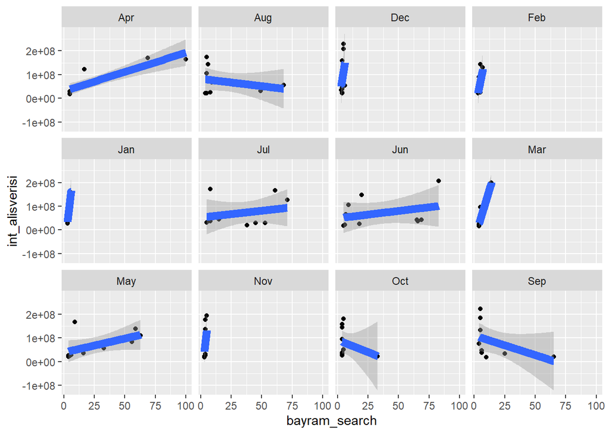

```r
ggplot(data,aes(x=bayram_search,y=int_alisverisi)) +
        geom_point() + geom_smooth(method=lm,linewidth=3) + facet_wrap(~mon)
```

Let’s inspect if our online shopping data is correlated with itself.

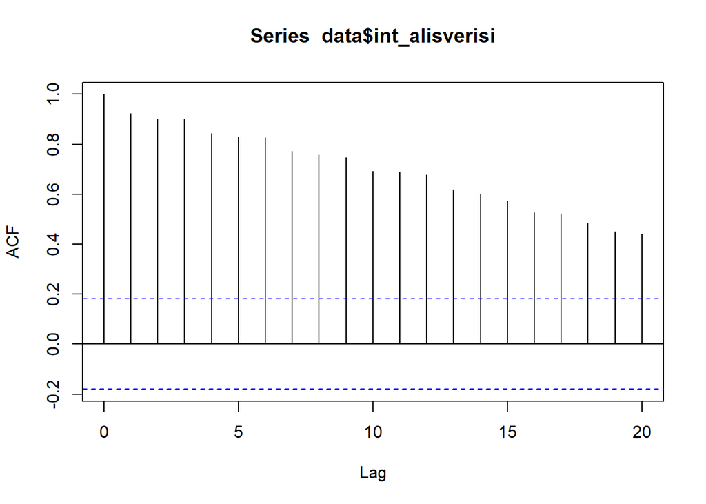

```r
acf(data$int_alisverisi)
```

With taking trend into consideration, let’s start to build our model. We observed the trend when we first inspected the visualization of the data.

```r
lm_base=lm(int_alisverisi~trnd,data)
summary(lm_base)
```

```
##
## Call:
## lm(formula = int_alisverisi ~ trnd, data = data)
##
## Residuals:
##       Min        1Q    Median        3Q       Max
## -40682409 -19081905  -1448897  15327833  64569918
##
## Coefficients:
##              Estimate Std. Error t value Pr(>|t|)
## (Intercept) -19318493    4619140  -4.182 5.63e-05 ***
## trnd          1561078      67374  23.171  < 2e-16 ***
## ---
## Signif. codes:  0 '***' 0.001 '**' 0.01 '*' 0.05 '.' 0.1 ' ' 1
##
## Residual standard error: 24930000 on 116 degrees of freedom
## Multiple R-squared:  0.8223, Adjusted R-squared:  0.8208
## F-statistic: 536.9 on 1 and 116 DF,  p-value: < 2.2e-16
```

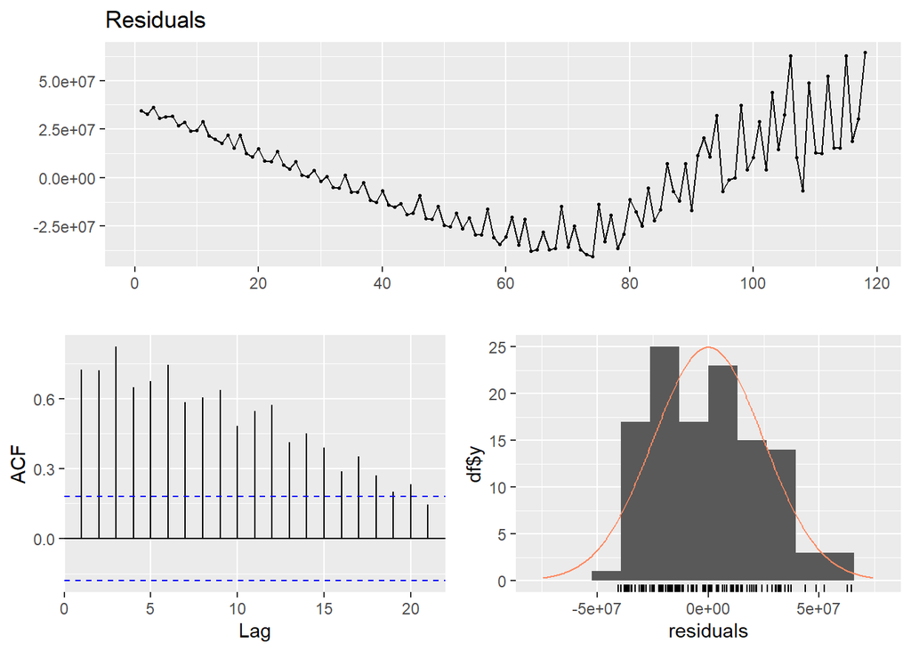

```
##
##  Ljung-Box test
##
## data:  Residuals
## Q* = 563.38, df = 10, p-value < 2.2e-16
##
## Model df: 0.   Total lags used: 10
```

```r
checkresiduals(lm_base$residuals)
```

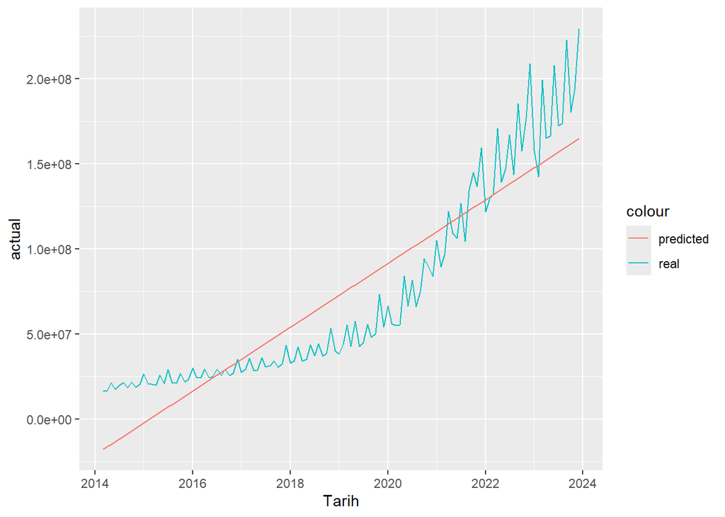

```r
tmp=copy(data)
tmp[,actual:=int_alisverisi]
tmp[,predicted_trend:=predict(lm_base,tmp)]
tmp[,residual_trend:=actual-predicted_trend]
#head(tmp)
ggplot(tmp ,aes(x=Tarih)) +
        geom_line(aes(y=actual,color='real')) +
        geom_line(aes(y=predicted_trend,color='predicted'))
```

```r
lm_base=lm(int_alisverisi~trnd+bayram_search,data)
summary(lm_base)
```

```
##
## Call:
## lm(formula = int_alisverisi ~ trnd + bayram_search, data = data)
##
## Residuals:
##       Min        1Q    Median        3Q       Max
## -40553715 -20138186  -1172183  15892445  65197685
##
## Coefficients:
##                Estimate Std. Error t value Pr(>|t|)
## (Intercept)   -19768402    4783222  -4.133 6.83e-05 ***
## trnd            1557883      68137  22.864  < 2e-16 ***
## bayram_search     39832     104175   0.382    0.703
## ---
## Signif. codes:  0 '***' 0.001 '**' 0.01 '*' 0.05 '.' 0.1 ' ' 1
##
## Residual standard error: 25020000 on 115 degrees of freedom
## Multiple R-squared:  0.8225, Adjusted R-squared:  0.8195
## F-statistic: 266.5 on 2 and 115 DF,  p-value: < 2.2e-16
```

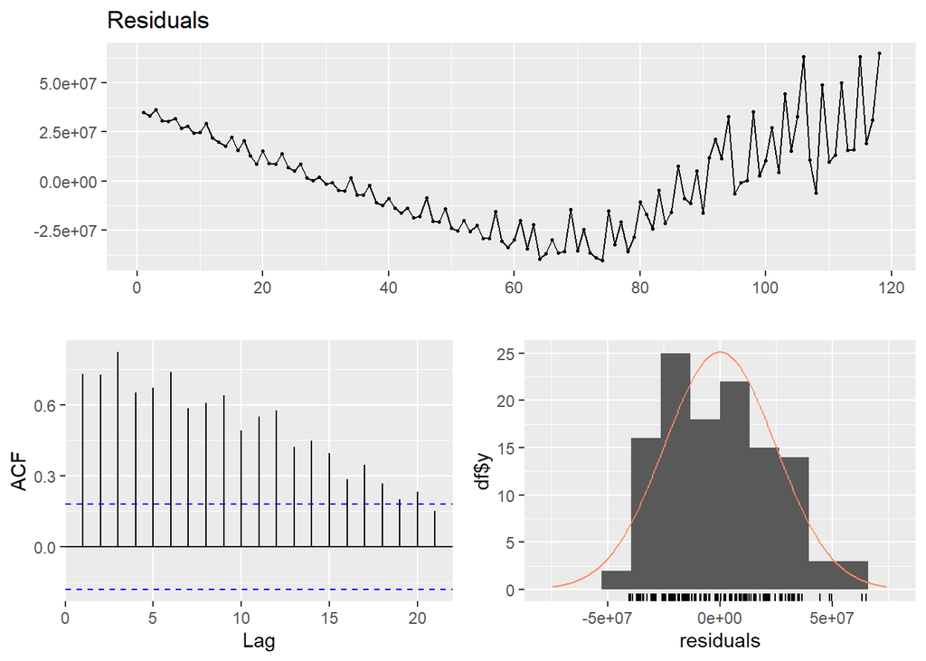

```
##
##  Breusch-Godfrey test for serial correlation of order up to 10
##
## data:  Residuals
## LM test = 95.031, df = 10, p-value = 5.354e-16
```

```r
checkresiduals(lm_base)
```

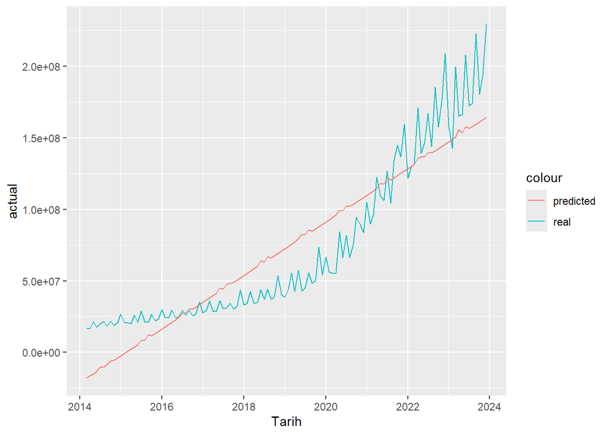

```r
tmp[,predicted_trend_bayram:=predict(lm_base,tmp)]
tmp[,residual_trend_bayram:=actual-predicted_trend_bayram]
ggplot(tmp ,aes(x=Tarih)) +
        geom_line(aes(y=actual,color='real')) +
        geom_line(aes(y=predicted_trend_bayram,color='predicted'))
```

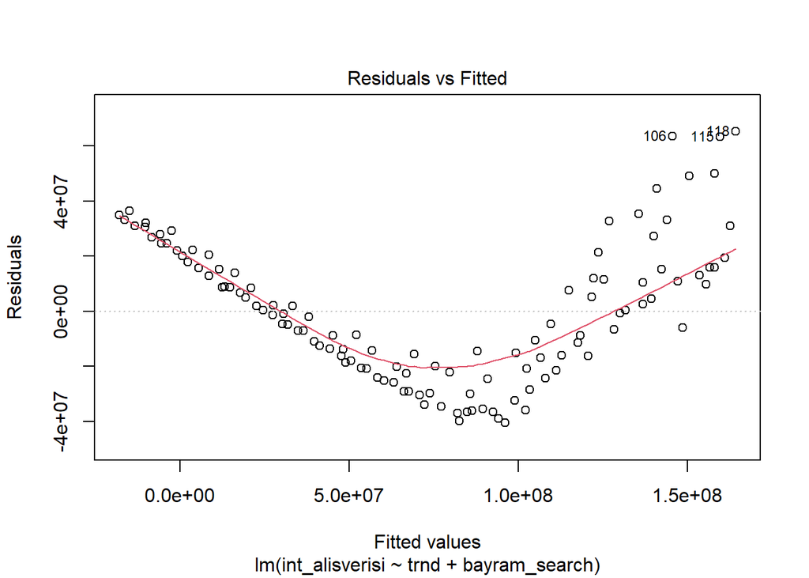

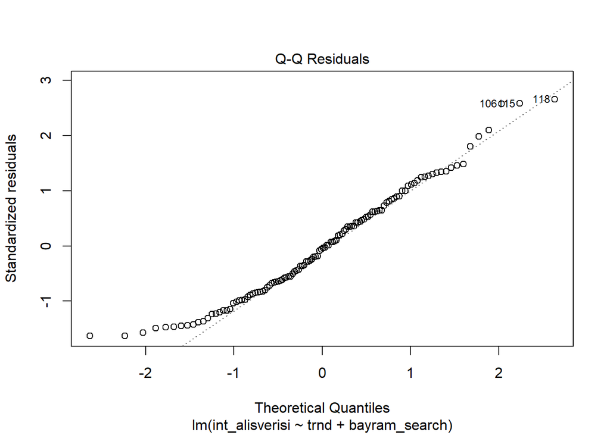

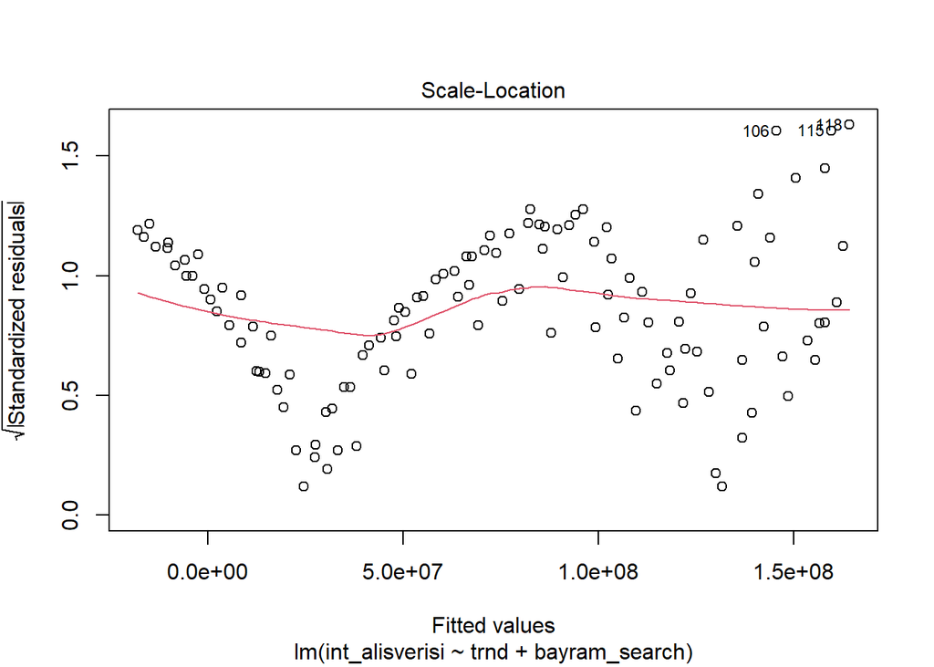

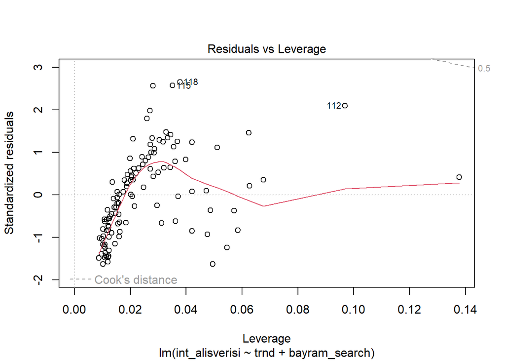

```r
plot(lm_base)
```

But now, it’s time to add the year “dummy variable” to our model, which will help make our model more accurate. With this method, we might also be able to observe the effect of seasonality.

```r
lm_base=lm((int_alisverisi)~trnd+(bayram_search)+yıl,data)
summary(lm_base)
```

```
##
## Call:
## lm(formula = (int_alisverisi) ~ trnd + (bayram_search) + yıl,
##     data = data)
##
## Residuals:
##       Min        1Q    Median        3Q       Max
## -30655055  -8730131   -892870   7052488  40130926
##
## Coefficients:
##                 Estimate Std. Error t value Pr(>|t|)
## (Intercept)      6129380    4416742   1.388  0.16812
## trnd             2326585     338273   6.878 4.38e-10 ***
## bayram_search      41760      52265   0.799  0.42607
## yıl2015        -21781172    6525306  -3.338  0.00117 **
## yıl2016        -45459734    9450560  -4.810 5.01e-06 ***
## yıl2017        -68532399   13002018  -5.271 7.20e-07 ***
## yıl2018        -89432457   16786221  -5.328 5.63e-07 ***
## yıl2019       -106301446   20679079  -5.141 1.26e-06 ***
## yıl2020       -111801873   24613230  -4.542 1.48e-05 ***
## yıl2021        -92997002   28591605  -3.253  0.00153 **
## yıl2022        -84088630   32597364  -2.580  0.01126 *
## yıl2023        -84325989   36606323  -2.304  0.02320 *
## ---
## Signif. codes:  0 '***' 0.001 '**' 0.01 '*' 0.05 '.' 0.1 ' ' 1
##
## Residual standard error: 12510000 on 106 degrees of freedom
## Multiple R-squared:  0.9591, Adjusted R-squared:  0.9548
## F-statistic: 225.9 on 11 and 106 DF,  p-value: < 2.2e-16
```

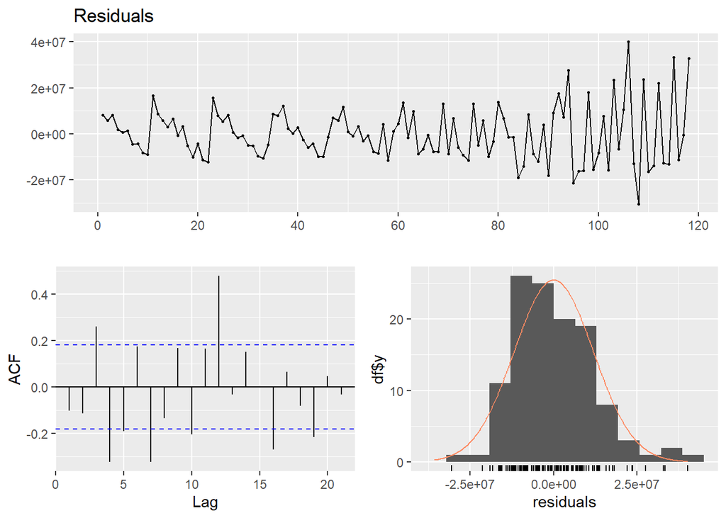

```
##
##  Breusch-Godfrey test for serial correlation of order up to 15
##
## data:  Residuals
## LM test = 75.722, df = 15, p-value = 4.192e-10
```

```r
checkresiduals(lm_base)
```

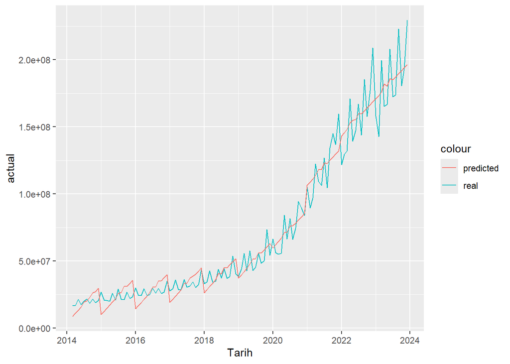

```r
tmp[,predicted_trend_bayram_yıl:=predict(lm_base,tmp)]
tmp[,residual_trend_bayram_yıl:=actual-predicted_trend_bayram_yıl]
ggplot(tmp ,aes(x=Tarih)) +
        geom_line(aes(y=actual,color='real')) +
        geom_line(aes(y=predicted_trend_bayram_yıl,color='predicted'))
```

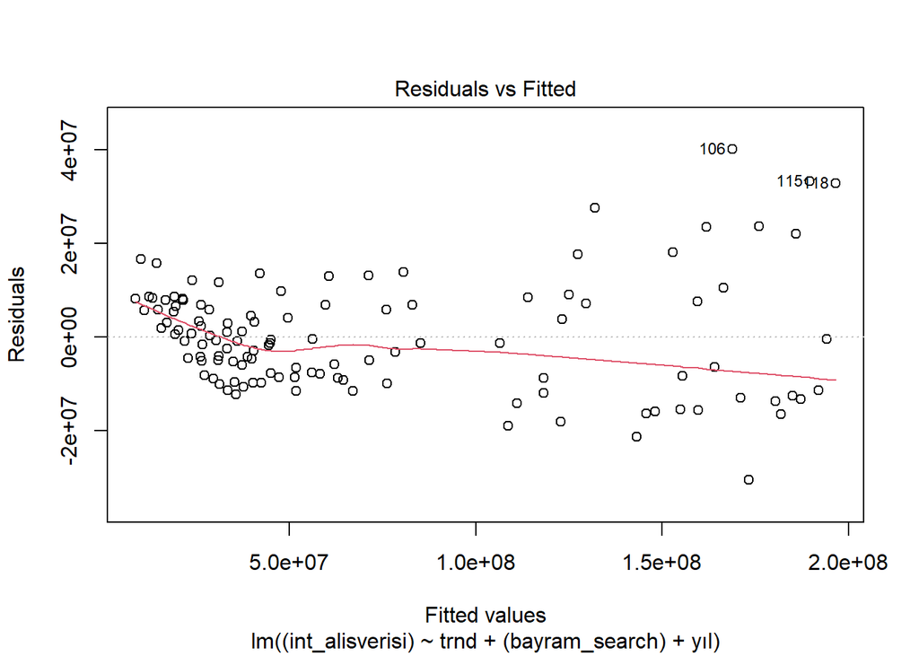

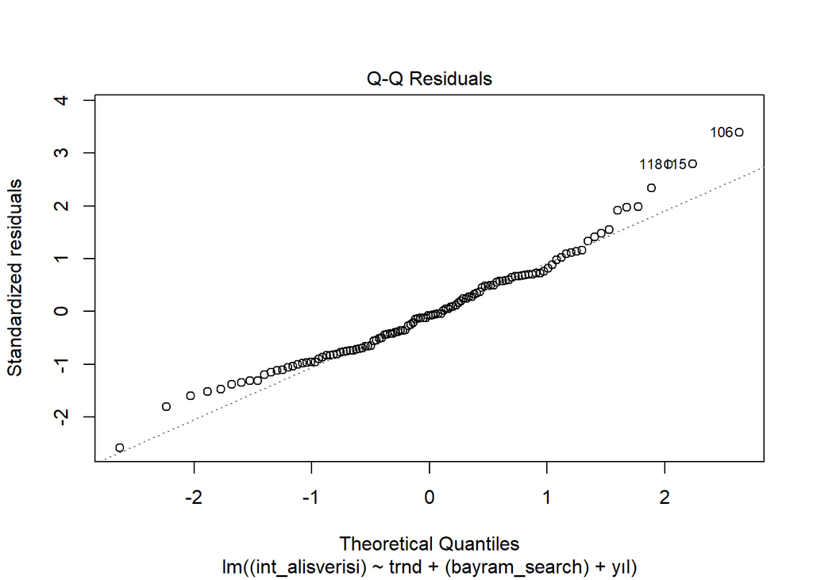

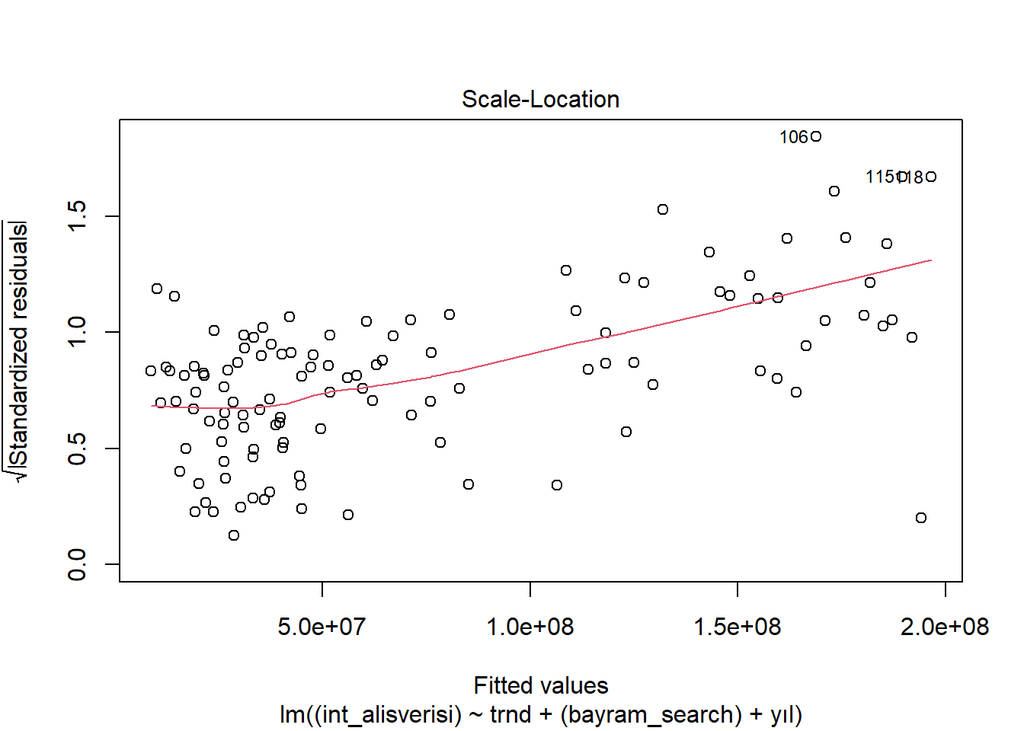

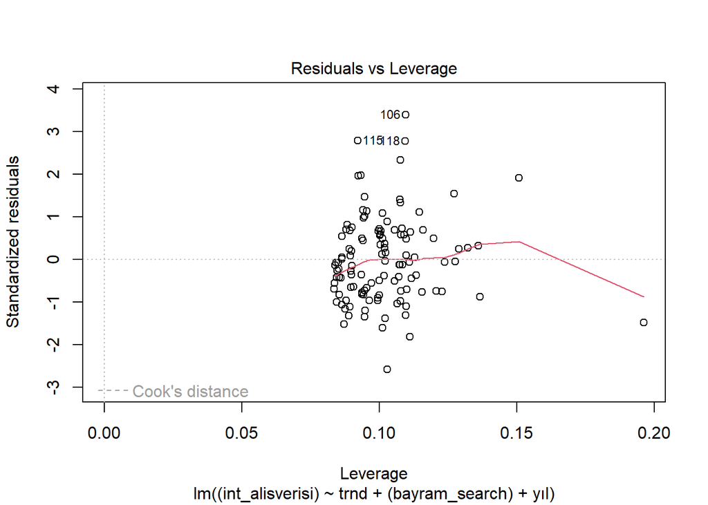

```r
plot(lm_base)
```

Now, we will check the if there is a relationship between the search for “sales”. As we may observe, there is not much of an improvement in our model.

```r
lm_base=lm((int_alisverisi)~trnd+(bayram_search)+yıl+indirim_search,data)
summary(lm_base)
```

```
##
## Call:
## lm(formula = (int_alisverisi) ~ trnd + (bayram_search) + yıl +
##     indirim_search, data = data)
##
## Residuals:
##       Min        1Q    Median        3Q       Max
## -30319439  -8809705   -328698   6708633  41945364
##
## Coefficients:
##                  Estimate Std. Error t value Pr(>|t|)
## (Intercept)       3264612    5127375   0.637  0.52570
## trnd              2227315     349854   6.366 5.19e-09 ***
## bayram_search       54991      53590   1.026  0.30718
## yıl2015         -21285599    6534689  -3.257  0.00152 **
## yıl2016         -44136566    9518239  -4.637 1.02e-05 ***
## yıl2017         -67052231   13059451  -5.134 1.31e-06 ***
## yıl2018         -88717448   16782799  -5.286 6.83e-07 ***
## yıl2019        -104482554   20725696  -5.041 1.94e-06 ***
## yıl2020        -108292857   24796829  -4.367 2.96e-05 ***
## yıl2021         -87251220   29040454  -3.004  0.00333 **
## yıl2022         -79924654   32786598  -2.438  0.01646 *
## yıl2023         -75828732   37382556  -2.028  0.04505 *
## indirim_search     156231     142416   1.097  0.27515
## ---
## Signif. codes:  0 '***' 0.001 '**' 0.01 '*' 0.05 '.' 0.1 ' ' 1
##
## Residual standard error: 12500000 on 105 degrees of freedom
## Multiple R-squared:  0.9595, Adjusted R-squared:  0.9549
## F-statistic: 207.6 on 12 and 105 DF,  p-value: < 2.2e-16
```

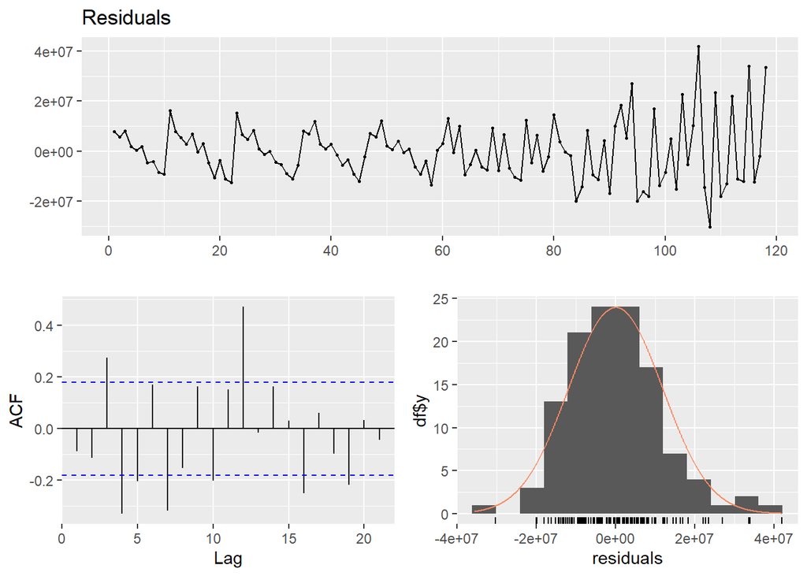

```
##
##  Breusch-Godfrey test for serial correlation of order up to 16
##
## data:  Residuals
## LM test = 77.758, df = 16, p-value = 4.207e-10
```

```r
checkresiduals(lm_base)
```

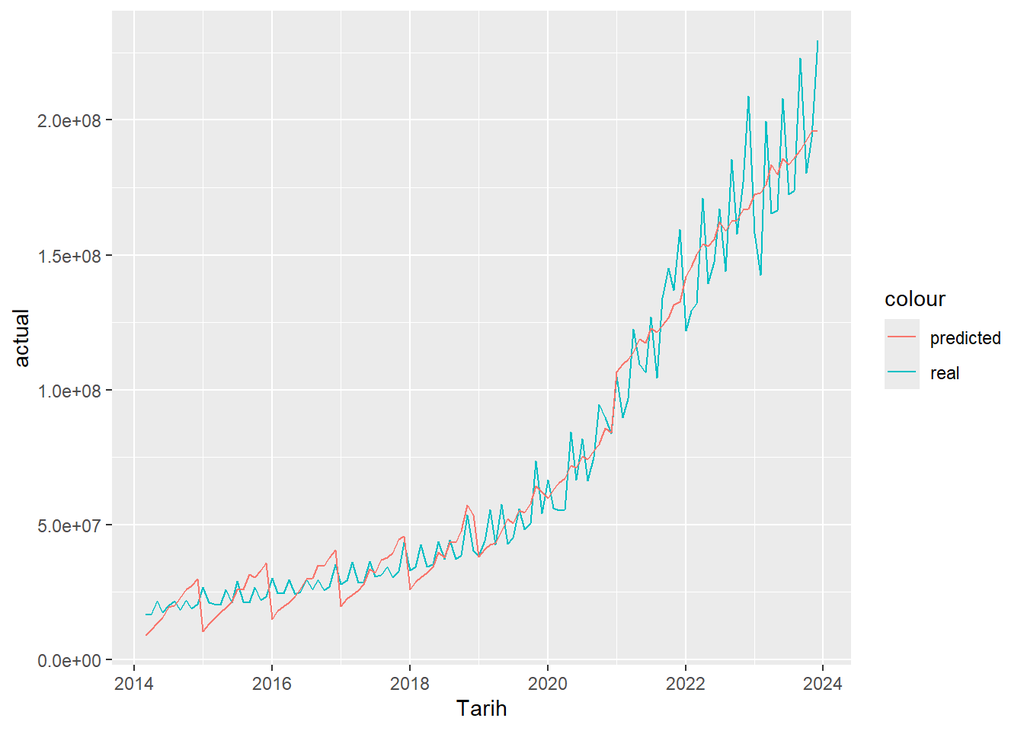

```r
tmp[,predicted_trend_bayram_yıl_indirim:=predict(lm_base,tmp)]
tmp[,residual_trend_bayram_yıl_indirim:=actual-predicted_trend_bayram_yıl_indirim]
ggplot(tmp ,aes(x=Tarih)) +
        geom_line(aes(y=actual,color='real')) +
        geom_line(aes(y=predicted_trend_bayram_yıl_indirim,color='predicted'))
```

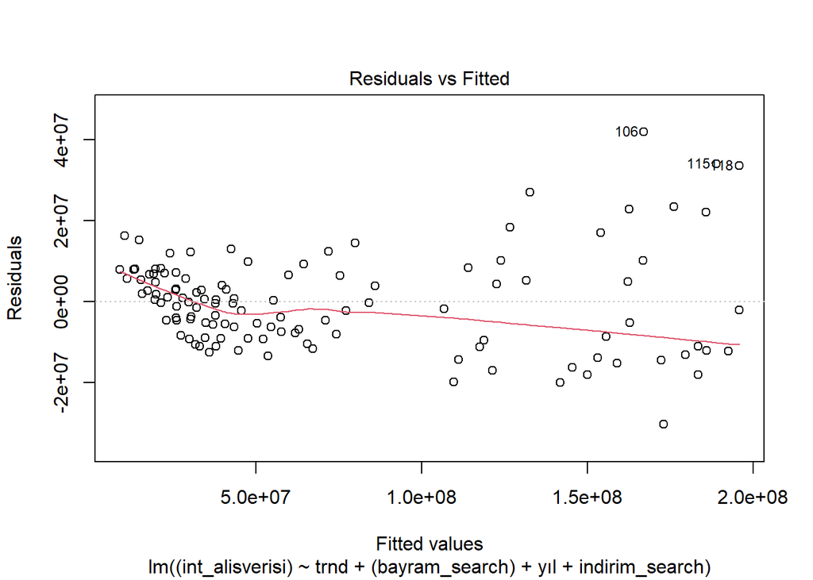

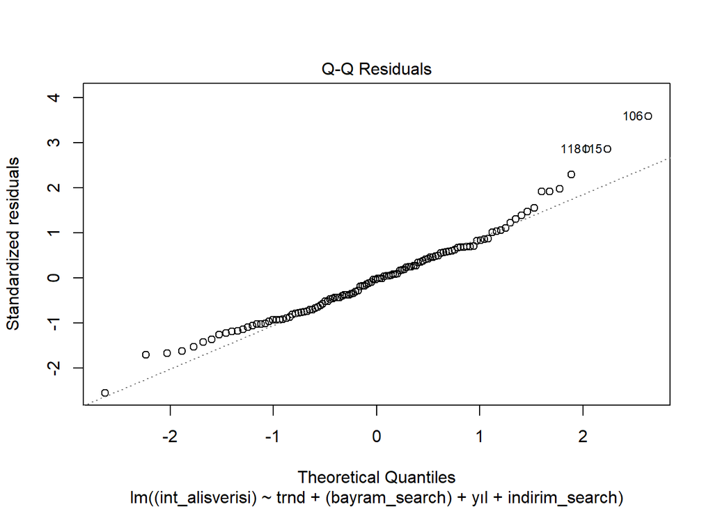

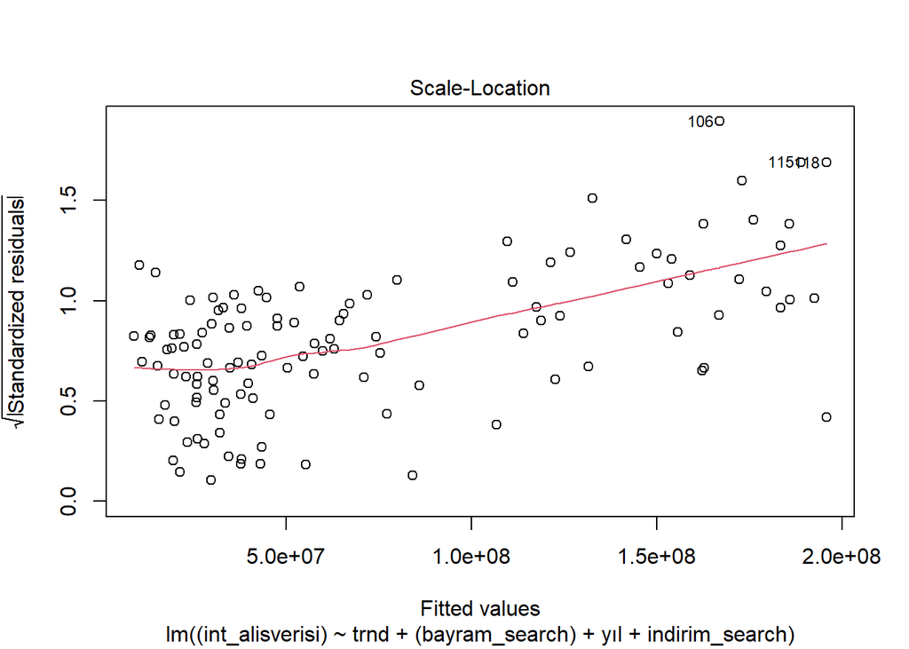

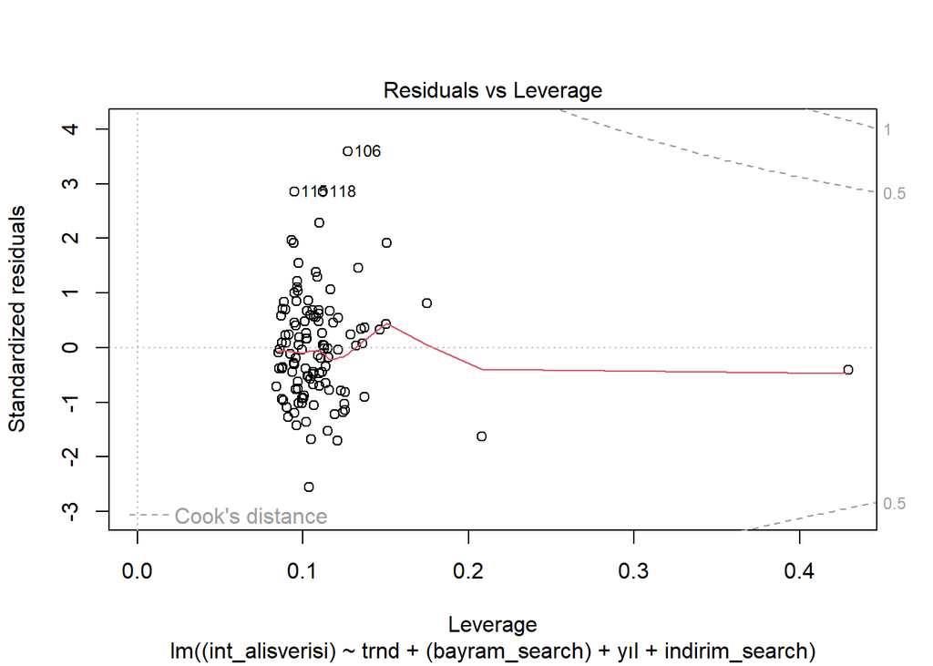

```r
plot(lm_base)
```

## Model 2

In this model, we will be looking at the “Consumer Confidence Index,” which is a measure of consumers’ optimism or pessimism about the economy’s prospects, and its impact on their spending and saving behavior.

Let’s check the data visualization first.

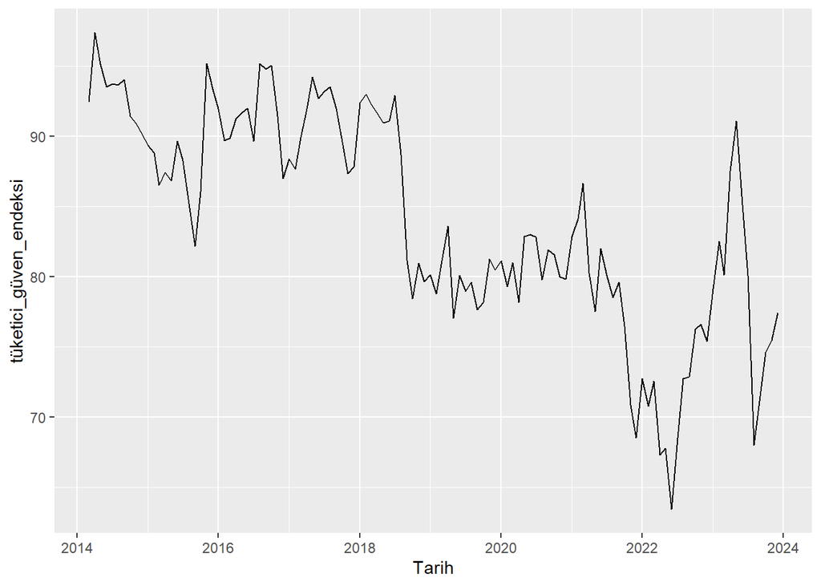

```r
ggplot(data ,aes(x=Tarih,y=tüketici_güven_endeksi, group=1)) + geom_line()
```

The commercial interest rate and real confidence index data seem like useful information to explain our data. Therefore, let’s add them to our model and examine their effects.

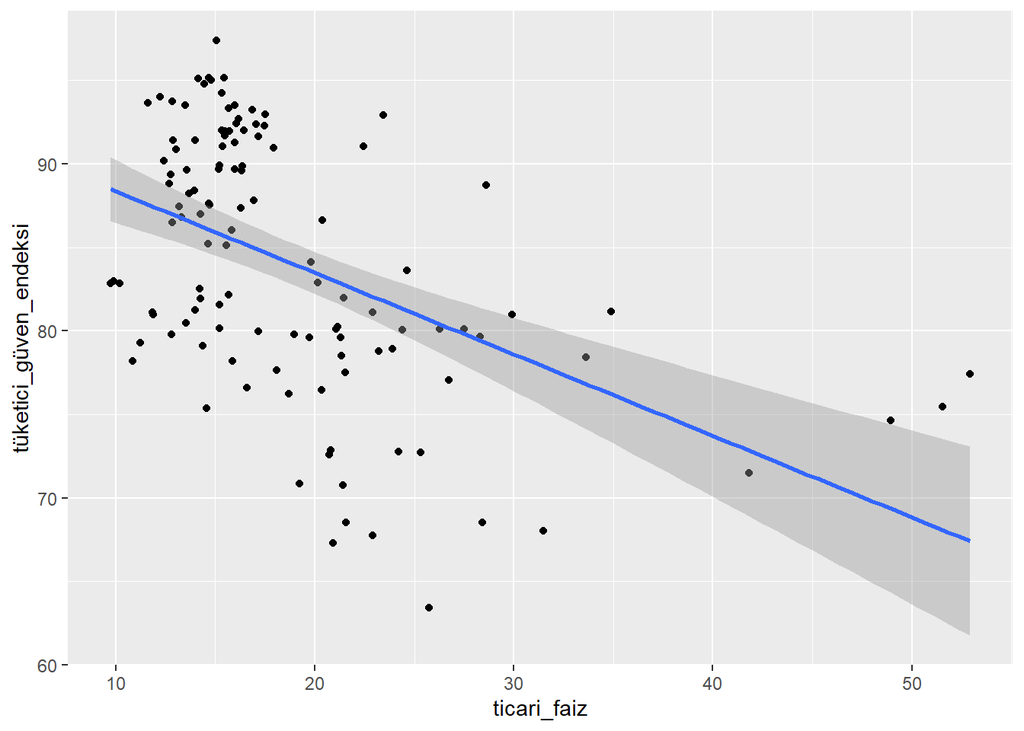

```r
ggplot(data ,aes(x=ticari_faiz,y=tüketici_güven_endeksi)) + geom_point() +geom_smooth(method='lm')
```

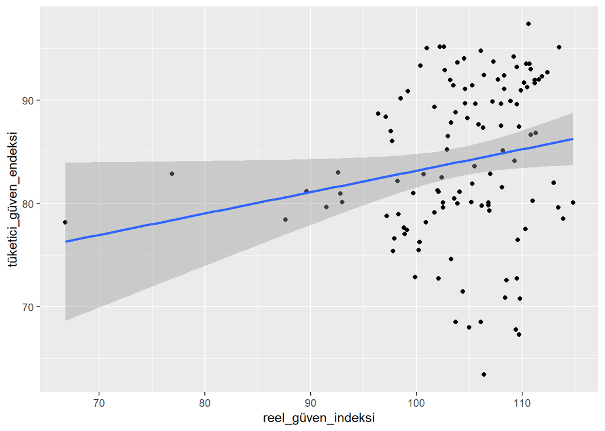

```r
ggplot(data ,aes(x=reel_güven_indeksi,y=tüketici_güven_endeksi)) + geom_point() +geom_smooth(method='lm')
```

By plotting the commercial interest rate and real confidence index data, let’s see if there is a monthly correlation.

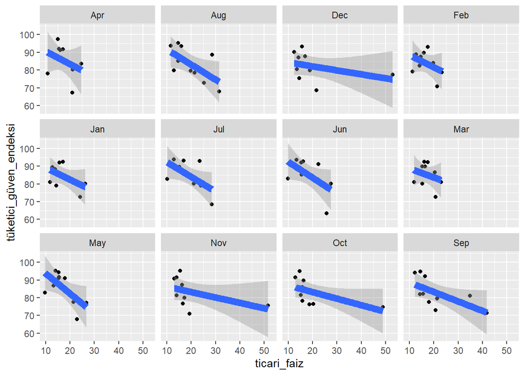

```r
ggplot(data,aes(x=ticari_faiz,y=tüketici_güven_endeksi)) +
        geom_point() + geom_smooth(method=lm,linewidth=3) + facet_wrap(~mon)
```

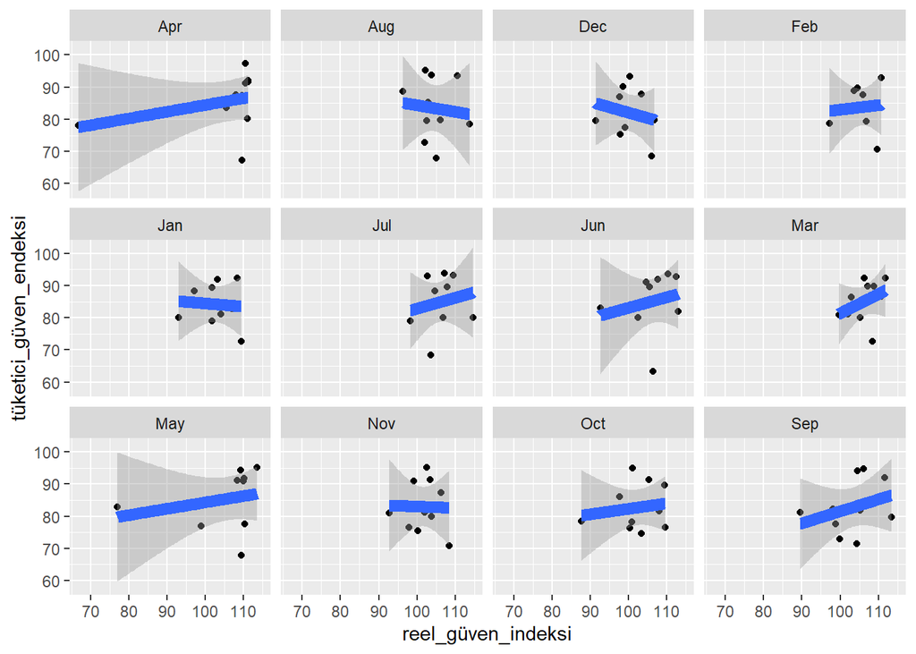

```r
ggplot(data,aes(x=reel_güven_indeksi,y=tüketici_güven_endeksi)) +
        geom_point() + geom_smooth(method=lm,linewidth=3) + facet_wrap(~mon)
```

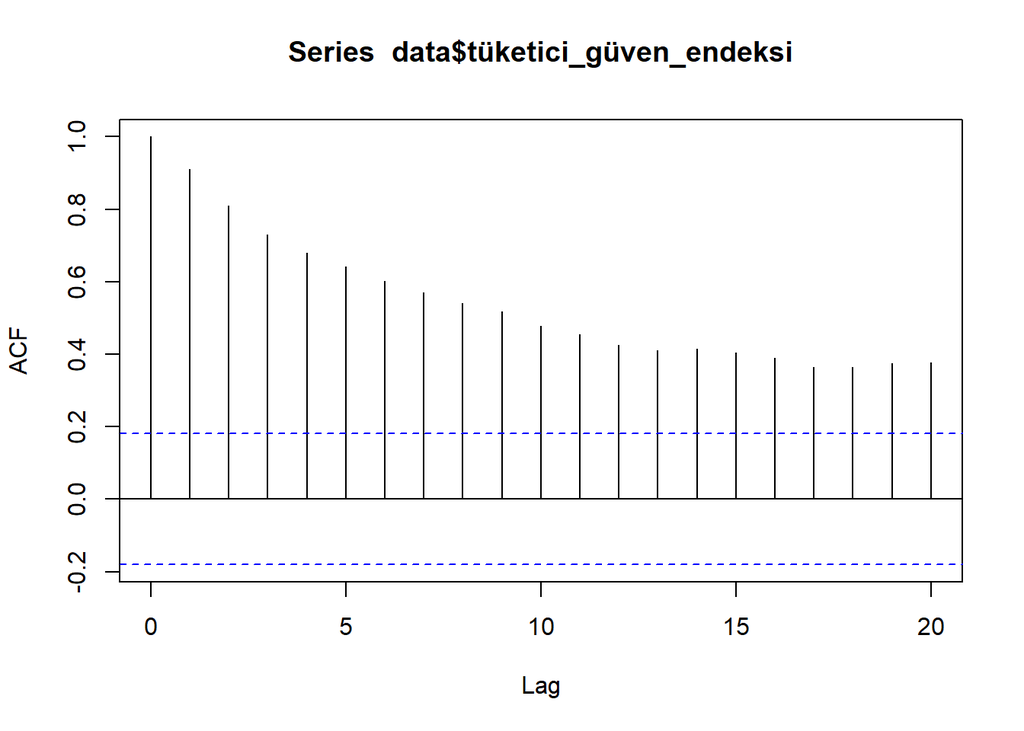

```r
acf(data$tüketici_güven_endeksi)
```

With taking trend into consideration, let’s start to build our model. We observed the trend when we first inspected the visualization of the data.

```r
lm_base1=lm(tüketici_güven_endeksi~trnd,data)
summary(lm_base1)
```

```
##
## Call:
## lm(formula = tüketici_güven_endeksi ~ trnd, data = data)
##
## Residuals:
##      Min       1Q   Median       3Q      Max
## -13.5108  -3.3070   0.0228   2.9564  16.0721
##
## Coefficients:
##             Estimate Std. Error t value Pr(>|t|)
## (Intercept) 94.49276    0.90051  104.93   <2e-16 ***
## trnd        -0.17572    0.01313  -13.38   <2e-16 ***
## ---
## Signif. codes:  0 '***' 0.001 '**' 0.01 '*' 0.05 '.' 0.1 ' ' 1
##
## Residual standard error: 4.86 on 116 degrees of freedom
## Multiple R-squared:  0.6068, Adjusted R-squared:  0.6034
## F-statistic:   179 on 1 and 116 DF,  p-value: < 2.2e-16
```

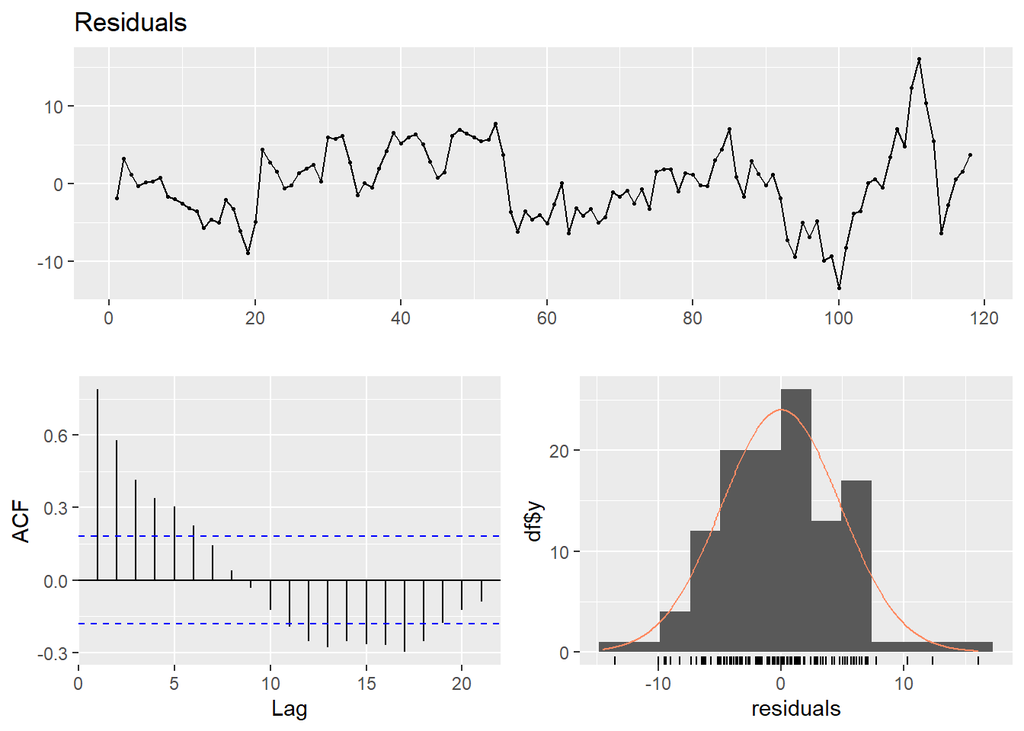

```
##
##  Ljung-Box test
##
## data:  Residuals
## Q* = 175.08, df = 10, p-value < 2.2e-16
##
## Model df: 0.   Total lags used: 10
```

```r
checkresiduals(lm_base1$residuals)
```

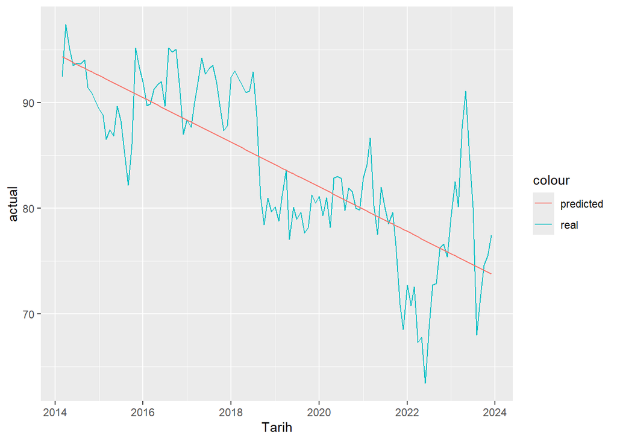

```r
tmp1=copy(data)
tmp1[,actual:=tüketici_güven_endeksi]
tmp1[,predicted_trend:=predict(lm_base1,tmp)]
tmp1[,residual_trend:=actual-predicted_trend]
#head(tmp)
ggplot(tmp1 ,aes(x=Tarih)) +
        geom_line(aes(y=actual,color='real')) +
        geom_line(aes(y=predicted_trend,color='predicted'))
```